# Cancer

Kevien Otieno

2023-10-14

#loading packages

```r
pacman::p_load(dplyr, tidyr, tidyverse, janitor, ggplot2, readxl,VennDiagram, lubridate)
```

#Cancer

```r
Cancer = read.csv("Cancer-studies.csv",
                   check.names = F,
                   na= "")
```

```r
#converting sex, Age and Study Status columns to factor
Cancer$Sex = as.factor(Cancer$Sex)
Cancer$Age = as.factor(Cancer$Age)
Cancer$`Study Status` = as.factor(Cancer$`Study Status`)
```

```r
# Create an empty vector to store the country names
country <- vector("character", length = nrow(Cancer))

# Loop through each row
for (i in 1:nrow(Cancer)) {
  # Split the "Locations" column for the current row
  row_splits <- unlist(str_split(Cancer$Locations[i], ","))

  # Calculate the number of countries for the current row
  length_loc <- length(row_splits)

  # Store the country name for the current row
  country[i] <- row_splits[length_loc]
}
```

```r
#creating a countries dataframe
country_df= data.frame(country)
```

```r
#grouping The column countries by the countries
Country_study =country_df %>%
  group_by(country) %>%
  summarise(`No of Studies` = n())
#arranging the dataset in descending order using the No of studies
Country_study = Country_study[order(Country_study$`No of Studies`, decreasing = TRUE), ]
#removing Nas
Country_study = Country_study %>%
  filter(!is.na(Country_study$country))
Country_study_top =head(Country_study, 10)
```

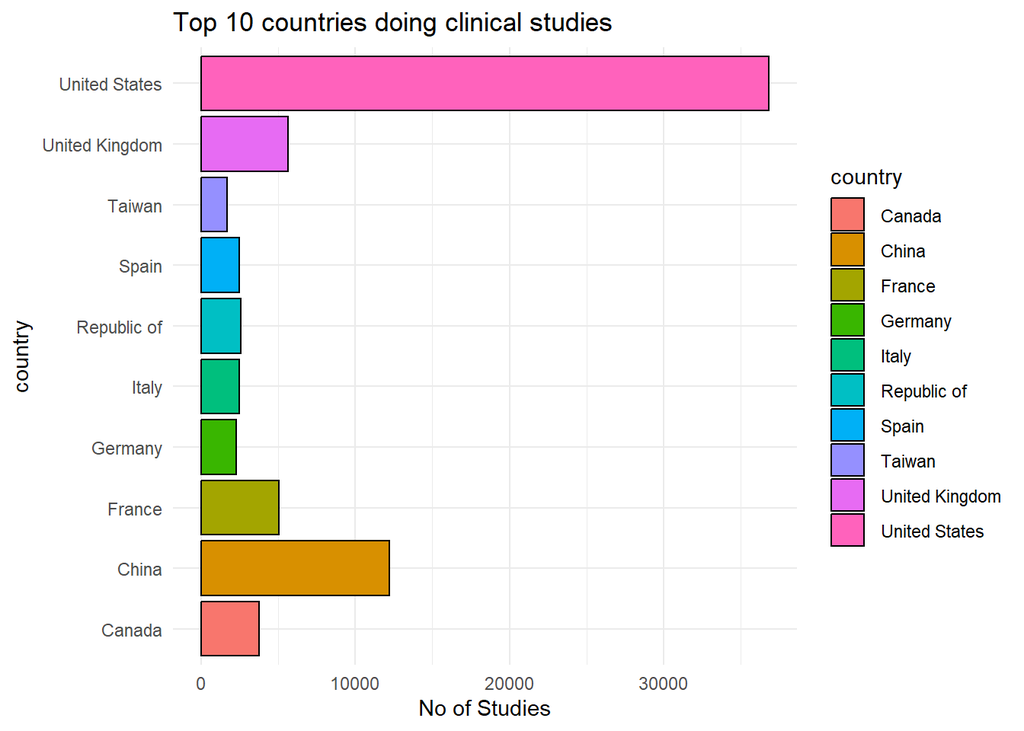

```r
ggplot(Country_study_top, aes(x=`No of Studies`, y=country,fill =country))+
  geom_bar(stat="identity", col= "black")+
  coord_cartesian(xlim = c(0,max(Country_study_top$`No of Studies`)))+
  labs(title = "Top 10 countries doing clinical studies")+
  theme_minimal()
```

From the studies conducted, United States leads on the No of studies being conducted. Recommendation: Countries In Africa should increase their research related to Cancer.

#To check if no of studies have been increasing over the years

```r
# Create an empty vector to store the years
year <- vector("character", length = nrow(Cancer))

for (i in 1:nrow(Cancer)) {
  # Split the "Locations" column for the current row
  row_splits1 <- unlist(str_split(Cancer$`Start Date`[i], "-"))

  # Store the country name for the current row
  year[i] <- row_splits1[1]
}
```

```r
#converting the year vector to a dataframe
year1 =data.frame(year)

#merging the year dataframe with the Cancer dataframe
Cancer = cbind(Cancer, year1)
```

```r
#converting year to numeric
Cancer$year <- as.numeric(Cancer$year)
```

```r
#grouping the years to the know the No of studies conducted each year
a= c(1,3,6,12,18,24,30,36,42,48,52)
year_studies = Cancer %>%
  group_by(year) %>%
  summarise(`No of studies` = n()) %>%
  filter(!is.na(year))
year_studies1=  year_studies[a, ]
```

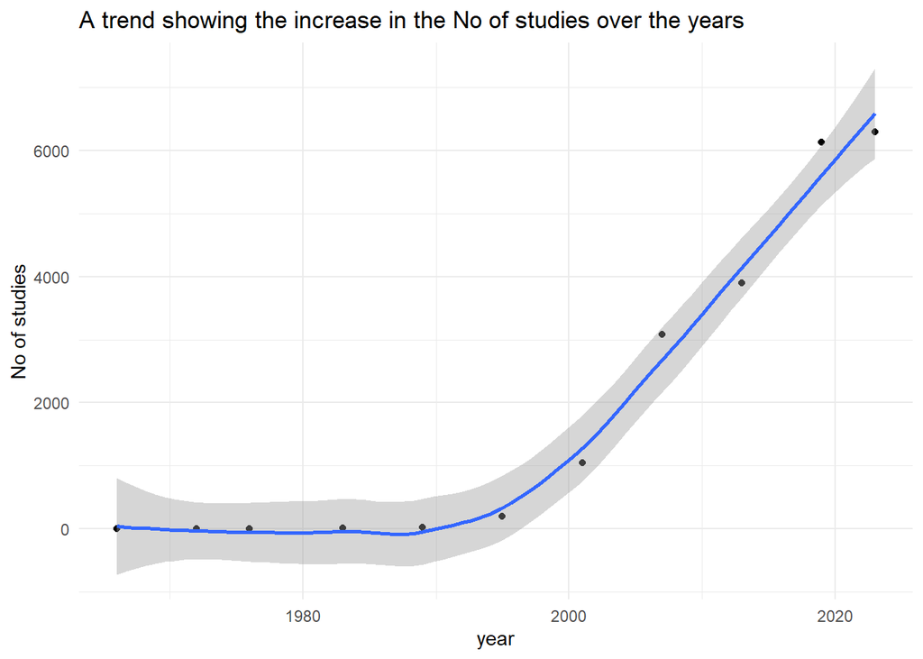

```r
#a line plot to show No of studies over years
ggplot(year_studies1, aes(x = year, y = `No of studies`)) +
  geom_point()+
  #geom_smooth(method = "loess") +
  geom_smooth(aes(group=1))+
  labs(title = "A trend showing the increase in the No of studies over the years") +
  theme_minimal()
```

The trend line shows an increase in the number of studies over years indicating that most countries are investing in research.

#conditons

```r
#extracting Conditons and calculating the number of each
Conditions = Cancer %>%
  group_by(Conditions) %>%
  summarise(`No of studies` = n())
#sorting the conditions by the No of studies
Conditions = Conditions[order(Conditions$`No of studies`,
                              decreasing = TRUE), ]
#top 5 conditions are being studied
plot_conditions =head(Conditions, 5)
```

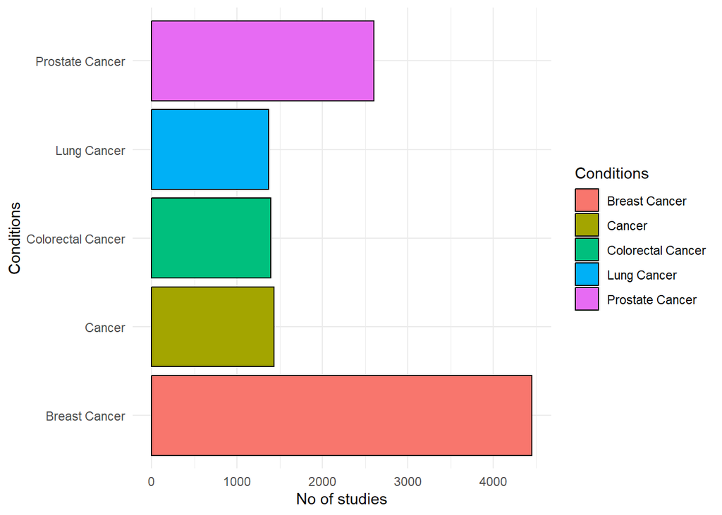

```r
#bar graph to show the leading condition
ggplot(plot_conditions, aes(x= `No of studies`, y = Conditions, fill= Conditions))+
  geom_bar(stat = "identity", col ="black")+
  coord_cartesian()+
  labs(Title= "Top five conditions being studied")+
  theme_minimal()
```

From graph, Most studies involve study on Breast Cancer.

#Interventions

```r
#grouping the interventions
Interventions = Cancer %>%
  group_by(Interventions) %>%
  summarise(`No of studies` = n())
#sorting the interventions using the No of Studies
Interventions = Interventions[order(Interventions$`No of studies` , decreasing = TRUE), ]
```

```r
#getting the top 10 interventions
Interventions_plot = head(Interventions, 10)
```

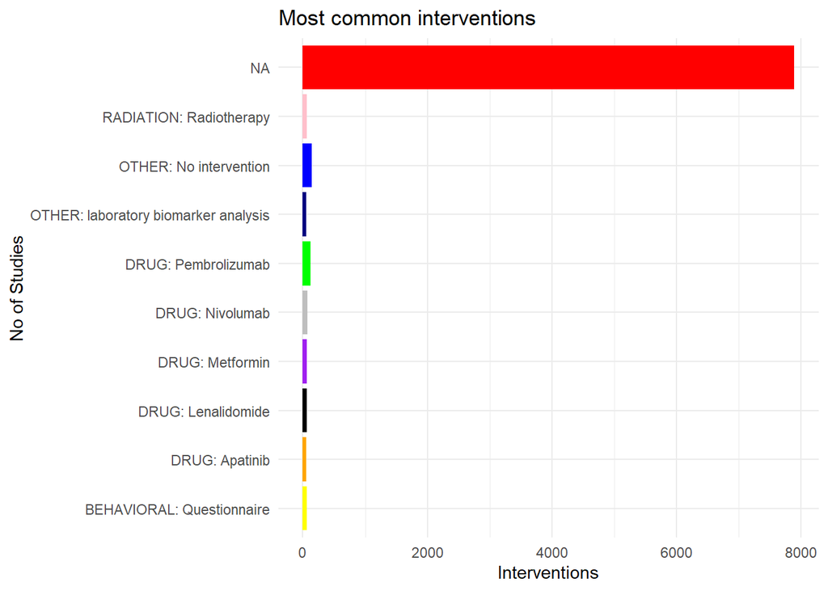

```r
#Bar plot to clearly display the interventions mostly used
ggplot(Interventions_plot, aes(x=`No of studies`, y=Interventions))+
  geom_bar(stat = "identity",fill=c("red","blue","green","gray","black","yellow","purple","pink","navy","orange"))+
  coord_cartesian()+
  labs(title = "Most common interventions", x= "Interventions", y ="No of Studies")+
  theme_minimal()
```

#Major Sponsors for the different clinical trials

```r
#Grouping the sponsors
Sponsors = Cancer %>%
  group_by(Sponsor) %>%
  summarise(`No of studies` =n())
#Sorting the sponsors according to the no of studies
Sponsors = Sponsors[order(Sponsors$`No of studies`, decreasing = TRUE), ]
```

```r
Sponsors_plot = head(Sponsors, 5)
```

#clear display of the lead sponsors

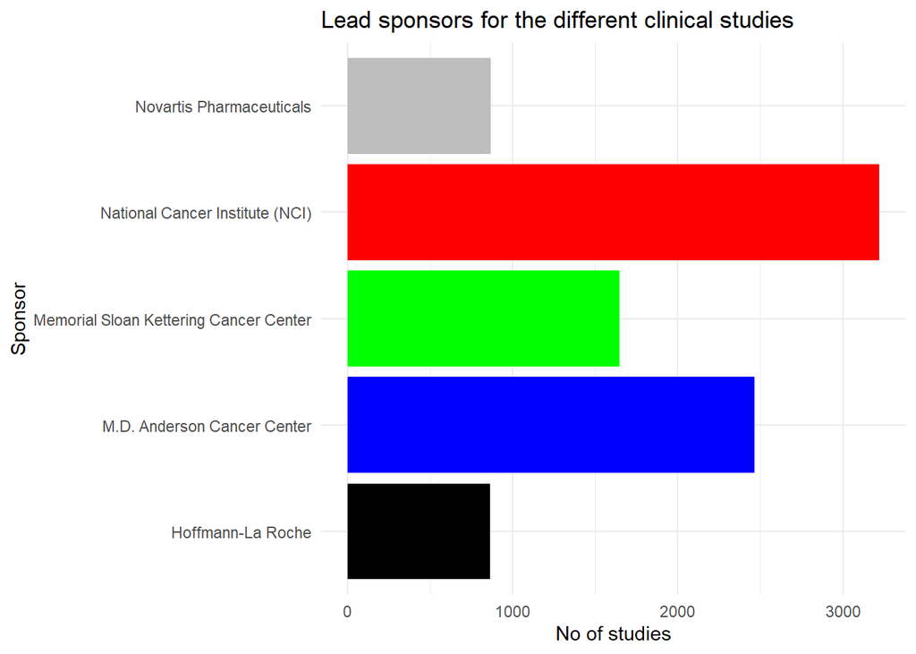

```r
ggplot(Sponsors_plot, aes(x= `No of studies`, y= Sponsor))+
  geom_bar(stat ="identity", fill= c("red","blue","green","gray","black"))+
  coord_cartesian()+
  labs(title ="Lead sponsors for the different clinical studies")+
  theme_minimal()
```

#colaborators

```r
#grouping the colaborators
colaborator= Cancer %>%
  group_by(Collaborators) %>%
  summarise(`No of studies`= n())
#sorting the colaborators in descending order
colaborator= colaborator[order(colaborator$`No of studies`, decreasing = TRUE), ]
```

```r
#obtaining the top 5 colaborators
top_colaborators= head(colaborator, 5)
```

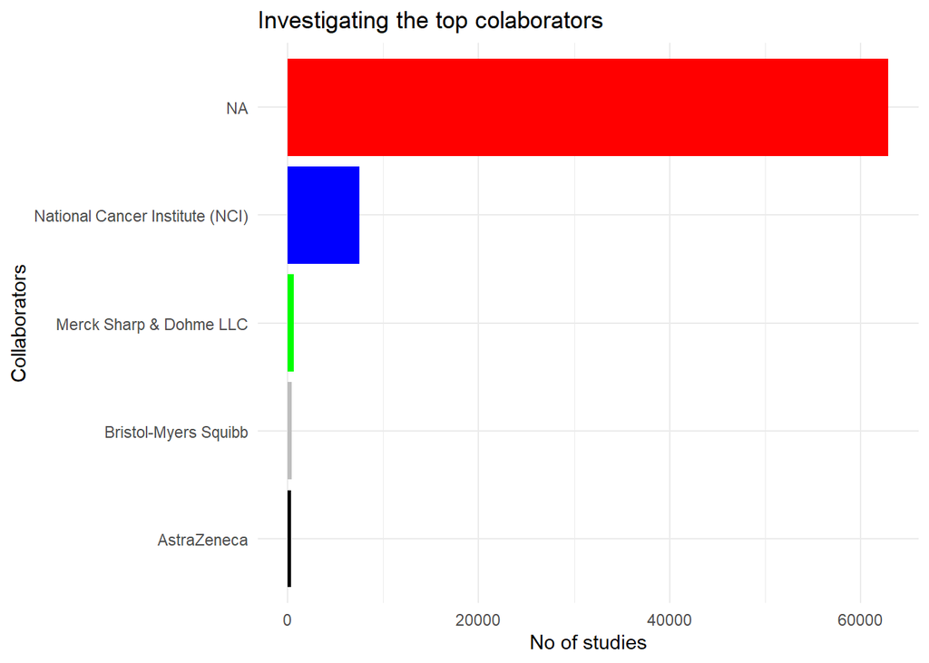

```r
#bar plot for a clear visual
ggplot(top_colaborators, aes(x=`No of studies`, y= Collaborators ))+
  geom_bar(stat = "identity",fill= c("red","blue","green","gray","black"))+
  coord_cartesian(xlim = c(0, max(top_colaborators$`No of studies`)))+
  labs(title= "Investigating the top colaborators")+
  theme_minimal()
```

The NA indicates that most studies lacked people collaborating with them

#Sex that is mostly involved in the study

```r
#Grouping people of different sex
Sex= Cancer %>%
  group_by(Sex) %>%
  summarise(`No of studies`= n()) %>%
  filter(!is.na(Sex))
```

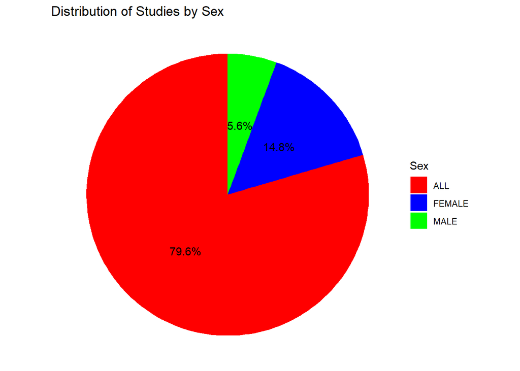

```r
# Calculate percentages
Sex$percentage4 <- Sex$`No of studies` / sum(Sex$`No of studies`) * 100

# Create a pie chart
ggplot(Sex, aes(x = "", y = `No of studies`, fill = Sex)) +
  geom_bar(stat = "identity", width = 1) +
  geom_text(
    aes(label = paste0(round(percentage4, 1), "%")),
    position = position_stack(vjust = 0.5)
  )+
  coord_polar("y") +
  labs(
    title = "Distribution of Studies by Sex",
    fill = "Sex"
  ) +
  theme_void() +
  theme(legend.position = "right") +
  scale_fill_manual(values = c("ALL" = "red", "FEMALE" = "blue", "MALE" = "green"))
```

From the pie chart most studies involved a combination of all genders.

#Investigating which Kind of age group are mostly involved in studies

```r
#grouping the age groups
age_group = Cancer %>%
  group_by(Age) %>%
  summarise(`No of studies`= n())
percentage = ((age_group$`No of studies`)/sum(age_group$`No of studies`, na.rm = TRUE))*100
```

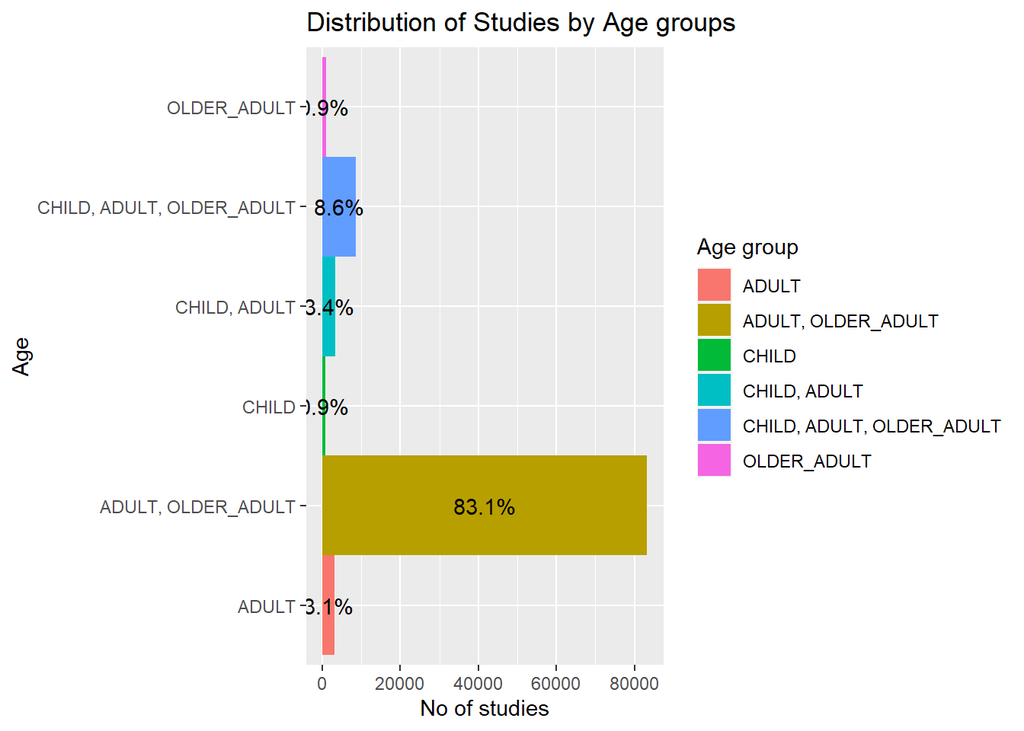

```r
# Create a pie chart
ggplot(age_group, aes(x = `No of studies`, y = Age, fill = Age)) +
  geom_bar(stat = "identity", width = 1) +
  geom_text(
    aes(label = paste0(round(percentage, 1), "%")),
    position = position_stack(vjust = 0.5)
  )+
  labs(
    title = "Distribution of Studies by Age groups",
    fill = "Age group"
  ) +
  theme(legend.position = "right")
```

#Investigating the study status

```r
#grouping the data according to Study Status
study_status= Cancer %>%
  group_by(`Study Status`) %>%
  summarise(`No of Studies`= n())
#sorting No of studies in descending order
study_status= study_status[order(study_status$`No of Studies`, decreasing = TRUE), ]

#obtaining percentages for the different study status
percentage1= ((study_status$`No of Studies`)/sum(study_status$`No of Studies`))*100
```

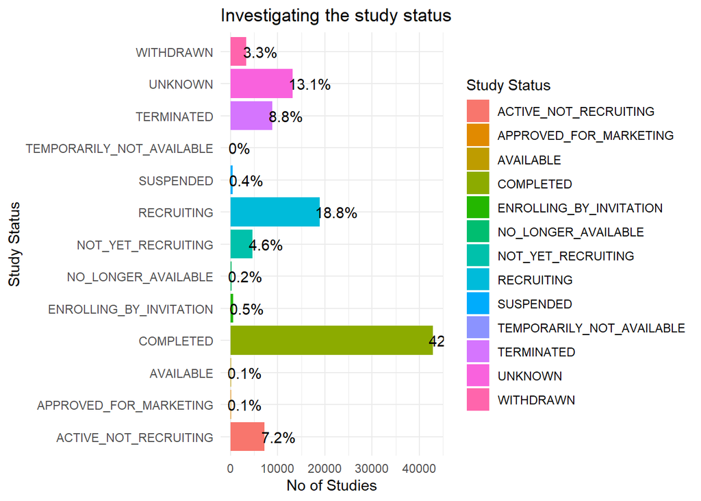

```r
ggplot(study_status, aes(x=`No of Studies`, y= `Study Status`, fill =`Study Status`))+
  geom_bar(stat = "identity")+
  coord_cartesian()+
  geom_text(aes(label= paste0(round(percentage1, 1), "%"), vjust = 0.5, hjust = 0.1))+
  labs(title = "Investigating the study status")+
  theme_minimal()
```

#Funder Type

```r
#grouping the Funder types
Funder.Type = Cancer %>%
  group_by(`Funder Type`) %>%
  summarise(`No of Studies`=n())
#obtaining the percentages
percentage2= ((Funder.Type$`No of Studies`)/sum(Funder.Type$`No of Studies`))*100
```

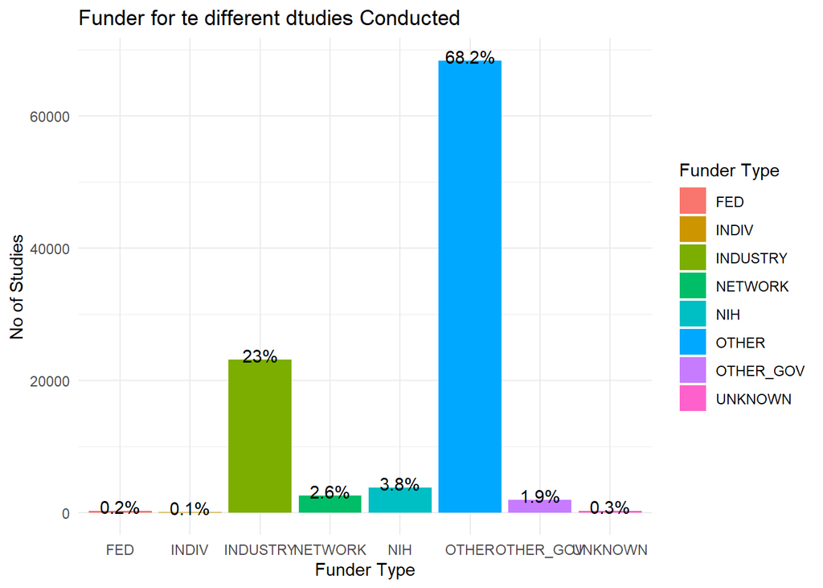

```r
ggplot(Funder.Type, aes(x=`Funder Type`, y = `No of Studies`, fill = `Funder Type`))+
  geom_bar(stat = "identity")+
  geom_text(aes(label=(paste0(round(percentage2,1),"%")),vjust = 0.2, hjust= 0.5))+
  labs(title = "Funder for te different dtudies Conducted")+
  theme_minimal()
```

#study type

```r
Study_type= Cancer %>%
  group_by(`Study Type`) %>%
  summarise(`No of Studies`= n())
```

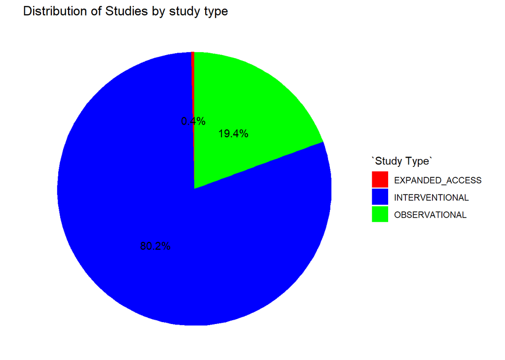

```r
# Calculate percentages
percentage5 <- Study_type$`No of Studies` / sum(Study_type$`No of Studies`) * 100

# Create a pie chart
ggplot(Study_type, aes(x = "", y = `No of Studies`, fill = `Study Type`)) +
  geom_bar(stat = "identity", width = 1) +
  geom_text(
    aes(label = paste0(round(percentage5, 1), "%")),
    position = position_stack(vjust = 0.5)
  )+
  coord_polar("y") +
  labs(
    title = "Distribution of Studies by study type",
    fill = "`Study Type`"
  ) +
  theme_void() +
  theme(legend.position = "right")+
  scale_fill_manual(values= c("INTERVENTIONAL" = "blue", "OBSERVATIONAL" = "green", "EXPANDED_ACCESS" = "red"))
```

From the graph most studies involved the use of a drug or Interventional.

#phases

```r
#grouping the data to different phases
Phases = Cancer %>%
  group_by(Phases) %>%
  summarise(`No of Studies`= n()) %>%
  filter(!is.na(Phases)) %>%
  filter(Phases != "NA")
#obtaining the percentages
percentage3= ((Phases$`No of Studies`)/sum(Phases$`No of Studies`))*100
```

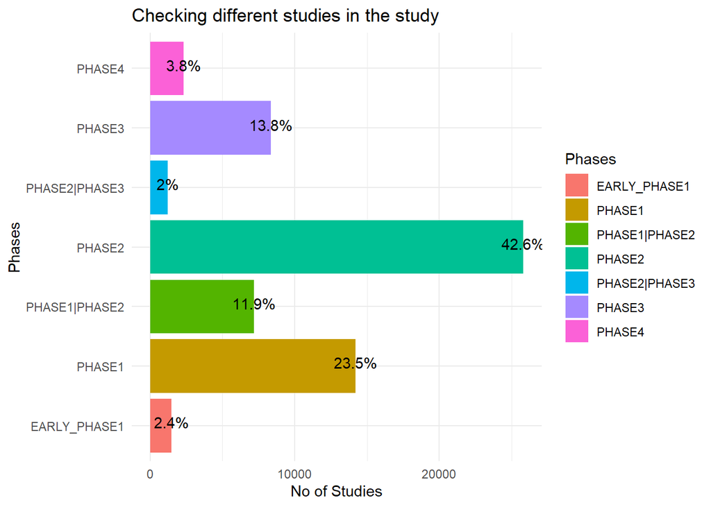

```r
ggplot(Phases, aes(x= `No of Studies`, y= Phases, fill= Phases))+
  geom_bar(stat = "identity")+
  coord_cartesian()+
  geom_text(aes(label=(paste0(round(percentage3,1),"%")),vjust = 0.2, hjust= 0.5))+
  labs(title = "Checking different studies in the study")+
  theme_minimal()
```

#Study results

```r
#grouping the study results
Study_results = Cancer %>%
  group_by(`Study Results`) %>%
  summarise(`No of Studies`= n())
#obtaining the percentages
percentage4= ((Study_results$`No of Studies`)/sum(Study_results$`No of Studies`))*100
```

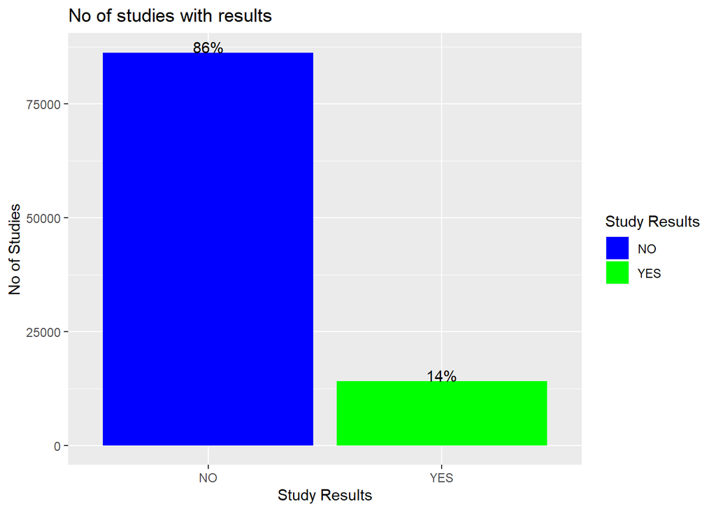

```r
ggplot(Study_results, aes(x=`Study Results`, y= `No of Studies`, fill =`Study Results`))+
  geom_bar(stat = "identity", )+
  geom_text(aes(label=(paste0(round(percentage4,1),"%")),vjust = 0, hjust= 0.5))+
  labs(title = "No of studies with results")+
  scale_fill_manual(values = c("NO"= "blue", "YES"= "green"))
```

From the graph we can clearly see that only a few of the studies yielded results.